# Project01_Test_A_Perceptual_Phenomenon

```python
import pandas as pd
import seaborn as sns
import matplotlib as plt
import math
from __future__ import division
% matplotlib inline
```

```python
df = pd.read_csv("stroopdata.csv")
```

```python
df.head()
```

|  | Congruent | Incongruent |
| --- | --- | --- |
| 0 | 12.079 | 19.278 |
| 1 | 16.791 | 18.741 |
| 2 | 9.564 | 21.214 |
| 3 | 8.630 | 15.687 |
| 4 | 14.669 | 22.803 |

# 1. Variables

1. The independent Variable is the congruent word condition
2. The Dependent Variable is completion time in seconds

# 2. Hypotheses and Statistical Test

The **dependent samples two-tailed t-test** will be used for this task, because:

```
* The dataset does not revealed the population mean and population-standardDeviation
* the sample size is less than 30
* We are measuring the time for either congruent and incongruent, without any direction of which one is better
```

### Null Hypothesis

- H0 = mean_incongruent - mean_congruent = 0
- there is very little difference in time between reading with congruent or incongruent words

### Alternative Hypothesis

- Ha = mean_incongruent - mean_congruent != 0
- there is very significant difference in time between reading with congruent or incongruent words

# 3. Descriptive Statistics

```python
#split congruent and incongruent data
congruent = df["Congruent"];
incongruent = df["Incongruent"]
```

#### congruent statistics

```python
congruent.describe()
```

```
count    24.000000
mean     14.051125
std       3.559358
min       8.630000
25%      11.895250
50%      14.356500
75%      16.200750
max      22.328000
Name: Congruent, dtype: float64
```

#### incongruent statistics

```python
incongruent.describe()
```

```
count    24.000000
mean     22.015917
std       4.797057
min      15.687000
25%      18.716750
50%      21.017500
75%      24.051500
max      35.255000
Name: Incongruent, dtype: float64
```

### Summary Table

| Measurement | Congruent | Incongruent |
| --- | --- | --- |
| Mean | 14.051125 | 22.015917 |
| Median | 14.3565 | 21.0175 |
| Standard Deviation | 3.559358 | 4.797057 |

# 4. Data Plot

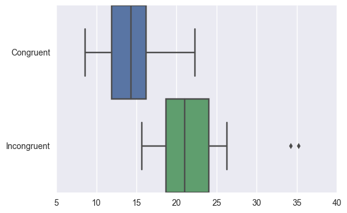

```python
sns.boxplot(data=df, orient="h",width=1, )
```

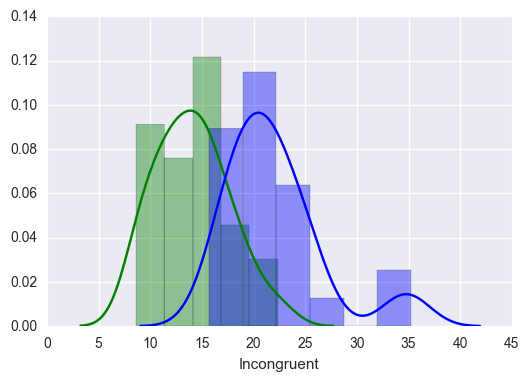

```python
congruent.rename("congruent")
incongruent.rename("incongruent")
sns.distplot(congruent, color="g")
sns.distplot(incongruent, color="b")
```

# Observation

From the boxplot above, we can see there are 2 outliers. The distribution plot also shows normal distribution for both congruent and incongruent, and similar to boxplot, there are outliers for incongruent graph

# 5. Statistical Test

- confidence level = 95%
- critical statistic value / alpha = 0.05
- n = 24
- df = 23
- Tcritical = +2.069 or -2.069

```python
# point_estimate
point_estimate = incongruent.mean() - congruent.mean()
# calculate standard deviation between Conruent & incongruent
difference = incongruent - congruent
S = difference.std()
S
```

```
4.8648269103590556
```

```python
# t-statistic
t =  point_estimate / (S / math.sqrt(24))
print t
```

```
8.02070694411
```

### T-statistic and Standard Deviation

- T-Statistic = 8.02070694411
- StandardDeviation = 4.8648269103590556

# Conclusion

T-statistic(8.02) is bigger than T-critical(2.069). So, the conclusion we reject the null hypothesis. **There is difference between 2 tests**.

# 6.Optional

1. What do you think is responsible for the effects observed?
   - we are used and taught to read the word, not the color. The participant have to break this automatic rule, which will take procressing time before saying the color instead of the written word.
2. Similar task that would result in a similar effect.
   - lying, or making up stories. Instead of describing with spoken word what we could remember from our memory. We have to stop and making up another story.